## Dataframes

Zusätzlich dazu gibt es in R mit den Dataframes noch eine weitere Struktur zur Speicherung von Daten verschiedener Typen. Dataframes können auch aus anderen Dateien (z.B. Excel Tabellen) importiert bzw exportiert werden.

```r
dat <- data.frame(x = 1:5, y = c("a", "b", "c", "d", "e"), hammerhai = 5:9)
dat$hammerhai               # Gibt die Spalte "hammerhai" von dat aus
```

```
## [1] 5 6 7 8 9
```

```r
dat[ , 3]                   # Gibt die dritte Spalte des Dataframes aus
```

```
## [1] 5 6 7 8 9
```

```r
dat$hammerhai[dat$x >= 3]   # Gibt die Spalte "hammerhai" von dat für alle
```

```
## [1] 7 8 9
```

```r
                            # Elemente mit der Spalte "x" größer gleich 3 aus
names(dat)
```

```
## [1] "x"         "y"         "hammerhai"
```

```r
str(dat)                    # Gibt die Struktur der einzelnen Variablen aus
```

```
## 'data.frame':    5 obs. of  3 variables:
##  $ x        : int  1 2 3 4 5
##  $ y        : chr  "a" "b" "c" "d" ...
##  $ hammerhai: int  5 6 7 8 9
```

```r
dat$schwertfisch <- 7:11    # Fügt dem Dataframe die Spalte schwertfisch hinzu

names(dat) <- c("apfel", "banane", "birne", "pfirsich")
# ändert die Namen der Variablen im Dataframe

dat2 <- data.frame(ananas = 2:6) # Erstellt neuen Dataframe
dat <- cbind(dat, dat2)          # Verbindet zwei Dataframes an der Spalte

customer_data <- read.csv("customers-100.csv")
# Quelle des Datensatzes: "https://www.datablist.com/learn/csv/download-sample-csv-files"

inventory_data <- read.table("sample.txt", sep = "\t", header = TRUE)
# Quelle des Datensatzes: "https://www.exceldemy.com/learn-excel/sample-data/"

View(customer_data)         # Zeigt den gesamten Dataframe an
head(customer_data, n = 5)  # Zeigt die ersten 5 Elemente an
```

```
##   Index     Customer.Id First.Name Last.Name                         Company
## 1     1 DD37Cf93aecA6Dc     Sheryl    Baxter                 Rasmussen Group
## 2     2 1Ef7b82A4CAAD10    Preston    Lozano                     Vega-Gentry
## 3     3 6F94879bDAfE5a6        Roy     Berry                   Murillo-Perry
## 4     4 5Cef8BFA16c5e3c      Linda     Olsen Dominguez, Mcmillan and Donovan
## 5     5 053d585Ab6b3159     Joanna    Bender        Martin, Lang and Andrade
##                City                    Country                Phone.1
## 1      East Leonard                      Chile           229.077.5154
## 2 East Jimmychester                   Djibouti             5153435776
## 3     Isabelborough        Antigua and Barbuda        +1-539-402-0259
## 4        Bensonview         Dominican Republic 001-808-617-6467x12895
## 5    West Priscilla Slovakia (Slovak Republic) 001-234-203-0635x76146
##                 Phone.2                       Email Subscription.Date
## 1      397.884.0519x718    zunigavanessa@smith.info        2020-08-24
## 2      686-620-1820x944             vmata@colon.com        2021-04-23
## 3   (496)978-3969x58947         beckycarr@hogan.com        2020-03-25
## 4       +1-813-324-8756 stanleyblackwell@benson.org        2020-06-02
## 5 001-199-446-3860x3486     colinalvarado@miles.net        2021-04-17
##                       Website
## 1  http://www.stephenson.com/
## 2       http://www.hobbs.com/
## 3    http://www.lawrence.com/
## 4  http://www.good-lyons.com/
## 5 https://goodwin-ingram.com/
```

```r
inventory_data <- inventory_data[inventory_data$Cost.Price.Per.Unit..USD. > 100, ]
# Speichert nurnoch die Items im Dataframe, deren Kosten über 100 USD liegen

write.table(inventory_data, file = "sample_output.txt", sep = "\t")

cars <- mtcars
cars$cyl <- factor(cars$cyl)
cars$gear <- factor(cars$gear)
meanpg <- mean(cars$mpg)
mean_mpg <- aggregate(mpg ~ gear + cyl,
                      data = cars,
                      FUN = mean)
```

## Plotting

Wie können wir nun Daten visualisieren? Wie können verschiedene Diagrammtypen erzeugt werden? Wie entsteht eine Legende? Weitere Plotfunktionen sind zudem auf dem cheatsheet zu finden.

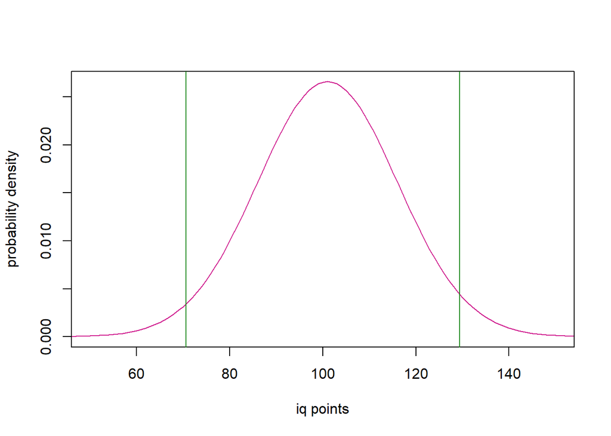

```r
plot(dnorm(0:200, mean = 100, sd = 15),
     type = "l",                           # Erzeugt eine Linie statt Punkten
     ylab = "probability density",         # Beschriftet die y Achse
     xlab = "iq points",                   # Beschriftet die x Achse
     xlim = c(50, 150),                    # Setzt die Grenzen für die x Achse
     col = "violetred")                    # Verändert die Farbe im Diagramm
abline(v = qnorm(.975, mean = 100, sd = 15), lty = 1, col = "forestgreen")
abline(v = qnorm(.025, mean = 100, sd = 15), lty = 1, col = "forestgreen")
```

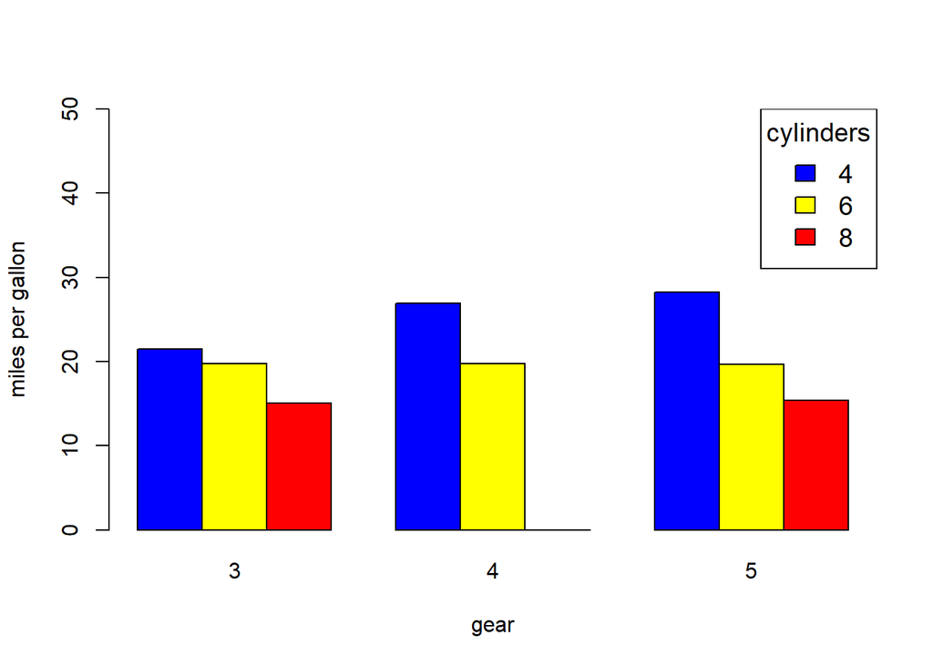

```r
# Erzeugt eine vertikale Linie an der Stelle x = v

# Folgendes Beispiel entstammt der Veranstaltung CgS1 der Kognitionswissenschaft
# von Julian Mollenhauer und Dr. Sascha Meyen
barplot(mpg ~ cyl + gear,
        col = c("blue", "yellow", "red"),
        ylim = c(0, 50),
        ylab = "miles per gallon",
        xlab = "gear",
        beside = TRUE,                      # Setzt zwei Balken nebeneinander
        data = mean_mpg)
legend("topright",
       legend = levels(cars$cyl),      # Legt die Bezeichnungen der Legende fest
       title = "cylinders",           # Gibt der Legende eine Überschrift
       fill = c("blue", "yellow", "red"), # Erzeugt kleine Farbboxen
       cex = 1.2)                         # Verändert die Größe der Legende
```

## Programmierung

Natürlich können auch in R eigene Funktionen geschrieben werden. Den Syntax für gängige Schleifen und Kontrollstrukturen schauen wir uns hier ebenfalls an.

```r
plusone <- function(x){
  x + 1
}

iseven <- function(x){
  if((x %% 2) == 0){
    TRUE
  }
  else{FALSE}
}

count_to_five <- function(x){
  for (i in x:5){
    print(i)
  }
}

take_it_down <- function(x){
  while(x != 0){
    if(x > 0){
      x <- x - 2
    } else{x <- x + 1}
    print(x)
  }
}
```

## R und Statistik

R besitzt viele nützliche eingebaute Funktionen um statistische Tests und Analysen durchzuführen. Angefangen von simplen Berechnungen wie dem Mittelwert oder Median über t-Tests bis hin zu Regressionsmodellen ist alles möglich. Dazu kommen viele Verteilungsfunktionen und Möglichkeiten zur Zufallsziehung von Werten aus diesen Verteilungen oder vorgegebenen Vektoren, mit denen wir uns nun beschäftigen wollen.

```r
# Würfeln bzw simple Ziehungen und Permutationen
dice <- 1:6
onehundredthrows <- sample(dice, 100,
                           replace = TRUE) # Ziehe 100 mal zufällig aus dice
mean(onehundredthrows) # Berechne den Mittelwert
```

```
## [1] 3.7
```

```r
var(onehundredthrows)  # Berechne die Varianz
```

```
## [1] 3.10101
```

```r
sd(onehundredthrows)   # Berechne die Standardabweichung
```

```
## [1] 1.760969
```

```r
permutated_dice <- sample(dice)

# Ziehen aus Verteilungen
set.seed(1893)                          # Seed zur Reproduzierbarkeit festlegen
iqdist <- rnorm(1000, mean = 100, sd = 15)   # Normalverteilung
binomvec <- rbinom(30, size = 1, prob = .7)  # Binomialverteilung
unifvec <- runif(100, min = 0, max = 1)      # Uniforme Verteilung

dnorm(100, mean = 100, sd = 15)   # Wie hoch ist die Wkeit für einen IQ von 100?
```

```
## [1] 0.02659615
```

```r
pnorm(100, mean = 100, sd = 15)   # Wie hoch ist die Wkeit für einen IQ <= 100?
```

```
## [1] 0.5
```

```r
qnorm(.9, mean = 100, sd = 15)    # Welchen IQ haben 90% der Menschen maximal?
```

```
## [1] 119.2233
```

```r
t.test(binomvec, mu = .8)             # Executes a t-Test on a dataset
```

```
##
##  One Sample t-test
##
## data:  binomvec
## t = -1.1751, df = 29, p-value = 0.2495
## alternative hypothesis: true mean is not equal to 0.8
## 95 percent confidence interval:
##  0.5259585 0.8740415
## sample estimates:
## mean of x
##       0.7
```

```r
summary(aov(hp ~ mpg, data = mtcars)) # Execute an ANOVA on a dataset
```

```
##             Df Sum Sq Mean Sq F value   Pr(>F)
## mpg          1  87791   87791   45.46 1.79e-07 ***
## Residuals   30  57936    1931
## ---
## Signif. codes:  0 '***' 0.001 '**' 0.01 '*' 0.05 '.' 0.1 ' ' 1
```

```r
summary(lm(hp ~ mpg, data = mtcars))  # Create a linear regression model of data
```

```
##
## Call:
## lm(formula = hp ~ mpg, data = mtcars)
##
## Residuals:
##    Min     1Q Median     3Q    Max
## -59.26 -28.93 -13.45  25.65 143.36
##
## Coefficients:
##             Estimate Std. Error t value Pr(>|t|)
## (Intercept)   324.08      27.43  11.813 8.25e-13 ***
## mpg            -8.83       1.31  -6.742 1.79e-07 ***
## ---
## Signif. codes:  0 '***' 0.001 '**' 0.01 '*' 0.05 '.' 0.1 ' ' 1
##
## Residual standard error: 43.95 on 30 degrees of freedom
## Multiple R-squared:  0.6024, Adjusted R-squared:  0.5892
## F-statistic: 45.46 on 1 and 30 DF,  p-value: 1.788e-07
```

## Übungsaufgabe

Die Universität Tübingen veröffentlicht in jedem Semester Statistiken zu den einzelnen Studiengängen, darunter auch zur Kognitionswissenschaft. Wie könnte man aus diesen Daten visuell ansprechende Diagramme erzeugen, die die Entwicklung der Studierendenzahlen in der Kognitionswissenschaft über die Semester verteilt veranschaulicht?

Dazu verwenden wir den Datensatz zum vergangenen Jahr (WS2022/23 + SS2023). Im Diagramm soll die Anzahl der Studierenden in Abhängigkeit des Fachsemesters (ab dem 3. und bis zum 10. Semester) und des angestrebten Abschlusses dargestellt werden. Auf eine Legende sollte dabei nicht verzichtet werden.

Hinweis: Eine sinnvolle Visualisierung dieser Daten ist ein gruppiertes Balkendiagramm. Dabei werden die Anzahl Bachelor- und Masterstudierende für jedes Semester nebeneinander als Balken dargestellt.

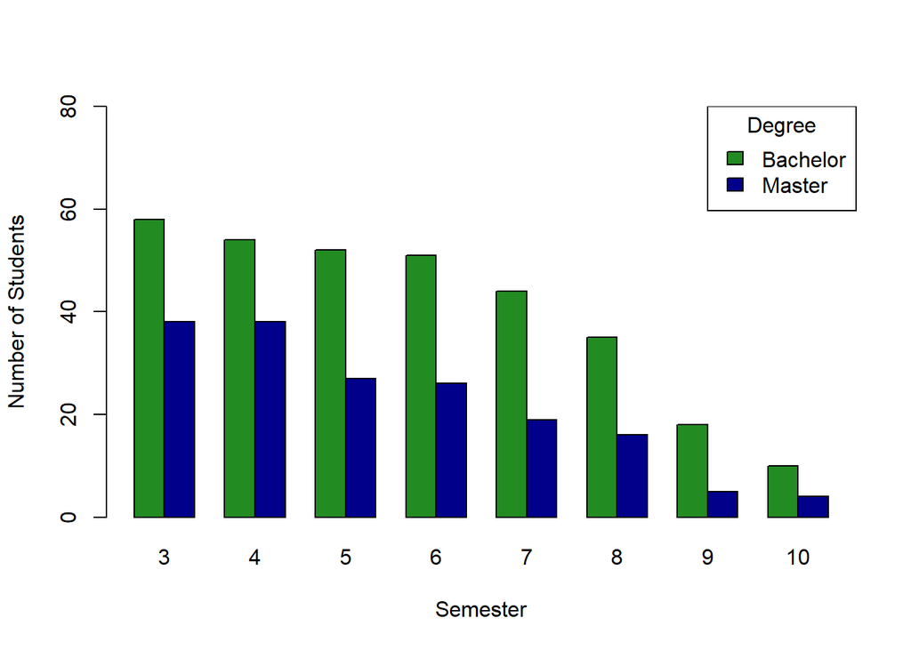

```r
# read the .csv file into a dataframe
students <- read.csv("cogsci_students_tuebingen_w22-s23.csv", sep = ";")

students <- students[students$semester >= 3 & students$semester <= 10,]

# plot the data using the dataframe students with two seperate bars for every
# semester
barplot(value ~ degree + semester,
        data = students,
        xlab = "Semester",
        ylab = "Number of Students",
        ylim = c(0, 80),
        beside = TRUE,
        col = c("forestgreen", "darkblue"))

# create a legend to show the difference between bachelors and masters students
legend("topright",
       title = "Degree",
       legend = c("Bachelor", "Master"),
       fill = c("forestgreen", "darkblue"))
```

Weiter